# kommunrapport_master

[figure not shown]

Kungsör

Kommunrapport

Resultat från undersökningen  
Liv & hälsa ung 2026

Framtagen av ledningsstabens analysenhet vid Regionala utvecklingsförvaltningen, Region Västmanland

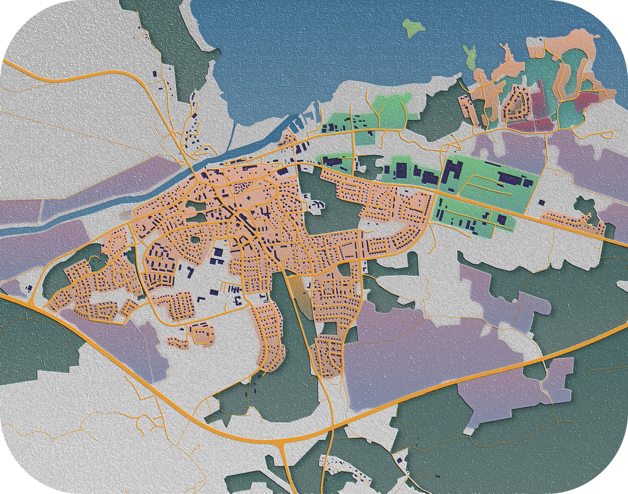

# Rapporten

Rapporten bygger på resultat från undersökningen *Liv & hälsa ung 2026*. Mer information om undersökningen finns i kapitlet **Om undersökningen**.

## Syfte

Syftet med rapporten är att ge Kungsör kommun en överskådlig bild av hur kommunens resultat från undersökningen Liv & hälsa ung förhåller sig till länssnittet inom olika områden. Rapporten är uppbyggd så att varje område först presenteras med ett sammanvägt indexvärde för området, följt av en nedbrytning i de enskilda indikatorer som indexet bygger på. På så sätt blir det möjligt att inte bara se det övergripande läget, utan också identifiera vad som driver resultatet och om det finns skillnader mellan killar och tjejer.

Rapporten kompletteras med en sambandsanalys som visar vilka områden och indikatorer som har störst betydelse för ungas mående. Sammantaget utgör rapporten ett underlag för att identifiera centrala utmaningar och prioritera insatser riktade till barn och unga i Kungsör .

## Metod

### Index

För beräkningen av delindexen används i första hand indikatorernas fullständiga svarsskalor, förutsatt att skalan enhetligt följer samma värderiktning. I de fall där den ursprungliga svarsskalan inte uppfyller detta krav, exempelvis där olika svarsalternativ representerar skilda situationer snarare än en graderad skala, används istället meningsfulla gruppindelningar som säkerställer en konsekvent värderiktning.

Varje indikator kodas om till skalan 0–10 och bidrar därefter med lika stor vikt till det delindex (område) den tillhör, oavsett hur många svarsalternativ eller grupper den ursprungligen består av. Delindexet beräknas som medelvärdet av de ingående indikatorerna och hamnar därmed alltid inom intervallet 0–10, vilket möjliggör jämförelser mellan områden.

Urvalet av indikatorer och konstruktionen av delindex har baserats på en kombination av statistiska analyser och konceptuella bedömningar. För varje delindex har vi undersökt om indikatorerna faktiskt mäter samma sak och hänger ihop med varandra på ett meningsfullt sätt, med hjälp av Cronbachs alfa (ett mått på intern konsistens) och principalkomponentanalys (PCA, en metod för att identifiera underliggande dimensioner i data). Indikatorer som visade sig mäta något i grunden annorlunda än övriga i ett index har prövats i andra index eller exkluderats. I de fall där ett område är brett och täcker flera delvis oberoende aspekter, som livsstil eller levnadsvillkor, har vi accepterat en lägre statistisk sammanhållning när indikatorerna ändå bedömts konceptuellt relevanta och viktiga för kommunernas beslutsunderlag.

### Områdenas innehåll

- **Utsatthet** – erfarenheter av diskriminering, trakasserier, utfrysning, hot, våld och rån.
- **Trygghet** – upplevd trygghet i bostadsområdet, skolan, på allmän plats och vid fritidsaktiviteter.
- **Tillit och förtroende** – tillit till andra människor samt förtroende för kommunen, polisen och skolan.
- **Studiegång och resultat** – skolresultat och skolfrånvaro, exempelvis underkända betyg och skolk.
- **Socialt stöd och ensamhet** – ensamhet, vänskapsrelationer och tillgång till någon att prata med och få stöd av.
- **Skolmiljö och stöd** – trivsel, studiero, stöd i skolarbetet samt relationen till och bemötandet från lärare.
- **Samhällssyn** – syn på människors lika rättigheter, våld och skadegörelse samt tillit till nyhetsmedier.
- **Livsstil** – skärmtid, sömn, matvanor, träning och fysisk aktivitet.
- **Levnadsvillkor** – familjens ekonomiska och materiella förutsättningar samt förutsättningar för studier i hemmet.
- **Hälsoförutsättningar och riskfaktorer** – stress, självskadebeteende, problematisk användning av digitala medier, sömnproblem och framtidstro.
- **Hälsa** – allmänt mående, psykiskt välbefinnande och psykisk påfrestning.
- **Föräldrarelation** – relationen till föräldrar, upplevt stöd och tillit samt föräldrarnas regler och gränssättning.
- **Fritid** – föreningsdeltagande, organiserade fritidsaktiviteter, möjlighet att delta och nöjdhet med fritiden.
- **Delaktighet** – olika former av samhälls- och politiskt deltagande, såsom diskussioner, kontakter med beslutsfattare och demonstrationer.
- **ANTS** – alkohol, narkotika, tobak och nikotin samt spel om pengar.

### Områdena i ett strukturellt sammanhang

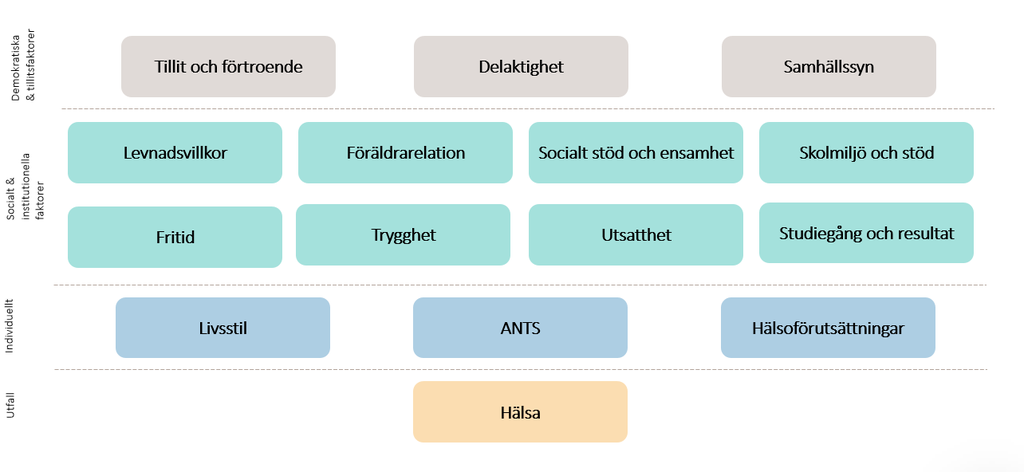

Bilden illustrerar en schematisk bild över hur rapportens områden förhåller sig till olika strukturella nivåer. Strukturen är inspirerad av Dahlgren och Whiteheads modell för hälsans bestämningsfaktorer (1991), men är anpassad utifrån de indikatorer och områden som faktiskt mäts i Liv och hälsa ung.

Modellen är ett analytiskt och pedagogiskt verktyg för att strukturera rapportens områden utifrån hur nära de ligger ungas vardag och hälsa. Den beskriver inte en exakt orsakskedja, i verkligheten samspelar områdena och många samband är ömsesidiga. Exempelvis kan hälsa påverka skolresultat, samtidigt som skolresultat kan påverka hälsa. Modellen belyser därför att olika områden kan påverkas genom insatser på olika nivåer och över olika långa tidsperspektiv.

Demokratiska och tillitsfaktorer utgör det yttersta lagret och inkluderar tillit och förtroende, delaktighet samt samhällssyn. Tillit och förtroende omfattar både mellanmänsklig tillit och förtroende för myndigheter och institutioner som skola, polis och kommun, faktorer som i stor usträckning formas av samhällsutvecklingen i stort. Delaktighet i samhällsfrågor påverkas förvisso av faktorer på lägre nivåer, som socialt stöd och individuella förutsättningar, men bedöms ändå tillhöra denna nivå eftersom graden av delaktighet också speglar hur samhällets strukturer möjliggör eller begränsar ungas inflytande. På liknande sätt påverkas samhällssynen, hur unga ser på frågor om mänskliga rättigheter, våld och medier, av normer och värderingar i det omgivande samhället.

Sociala och institutionella faktorer innefattar relationer och stöd från familj och vänner, men också faktorer kopplade till skolan som miljö, relationer och stöd från lärare. Hit hör även familjens socioekonomiska situation och de materiella levnadsvillkor den skapar, upplevd trygghet på olika platser samt erfarenheter av våld, hot och utsatthet. Fritid bedöms också vara en social och institutionell faktor, eftersom ungas möjligheter att delta i fritidsaktiviteter i hög grad formas av tillgång till arenor, ekonomiska förutsättningar och lokalt utbud, snarare än enbart individuella val. Hit hör även studiegång och resultat. Skolprestationer kan betraktas som ett utfall i sig då studieresultat följer samma sociala gradient som hälsa och påverkas i hög grad av samma underliggande faktorer. I den här rapporten är dock hälsa det primära utfallet, och studiegång och resultat behandlas därför som en av de faktorer som samvarierar med och kan bidra till att förklara ungas hälsa och välbefinnande. Placeringen motiveras också av det nära sambandet med skolmiljö och stöd.

Individuella faktorer innefattar livsstil, ANTS samt hälsoförutsättningar. Dessa faktorer speglar beteenden, vanor och riskfaktorer som i sin tur påverkas av de strukturella och sociala nivåerna ovanför.

Hälsa (allmänt månede) är utfallet för rapportens sambandsanalyser.

## Hur man läser rapporten

### Index

Delindexen visar kommunens sammanvägda resultat inom respektive område, baserat på de indikatorer som området består av. Indexvärdena rör sig mellan 0 och 10.

För samtliga områden gäller att ett högre indexvärde är mer önskvärt. Det innebär att ett högt värde på ANTS och Utsatthet speglar låg förekomst av ANTS-användning respektive låg grad av utsatthet, indikatorerna är inverterade innan indexberäkningen för att säkerställa en konsekvent värderiktning genom hela rapporten.

I den övergripande sammanfattningen av kommunens resultat används en gräns på ±0,2 indexenheter för att avgöra om ett område avviker meningsfullt från länssnittet. Gränsen baseras på den genomsnittliga variationen mellan kommuner i länet, där den typiska avvikelsen ligger på 0,10–0,20 indexenheter. Avvikelser under denna gräns bedöms som normal variation, medan avvikelser över 0,2 indexenheter lyfts fram som områden där kommunen sticker ut i förhållande till länet.

De områden och indikatorer som ingår i rapporten har valts ut för att vara så avgränsade och mätbara som möjligt, samtidigt som de tillsammans ger en tillräckligt bred bild av faktorer som är relevanta för ungas hälsa och välbefinnande. En grundläggande utgångspunkt i urvalet är att de flesta områden speglar förhållanden som går att påverka genom insatser från kommuner, skolor och andra aktörer som möter unga i vardagen.

Det är också viktigt att komma ihåg att områdena hänger ihop och kan påverka varandra. Möjligheten att påverka varierar. Inom vissa områden kan insatser ge resultat snabbare, medan andra förändras långsammare och kan påverkas mer av bredare samhällsfaktorer.

### Indikatorer

De enskilda indikatorerna presenteras som dikotomiserade andelar i resultatredovisningen, det vill säga andelen respondenter som tillhör en given grupp, exempelvis andelen som uppger god hälsa eller andelen som känner sig trygga. Detta görs för att underlätta läsbarheten och göra resultaten tillgängliga för en bred målgrupp. Till skillnad från indexvärdena redovisas enskilda indikatorer i frågans ursprungliga riktning. En hög andel kan därför innebära både en bättre situation, som hög andel trygga, och en sämre, som hög andel utsatta.

Det är värt att notera att dikotomiseringen enbart används i den deskriptiva resultatredovisningen. För beräkningen av delindexen används indikatorernas fullständiga svarsskalor eller gruppindelningar, i enlighet med vad som beskrivs ovan. En fullständig förteckning över samtliga frågor, ursprungliga svarsalternativ och hur de kodats i resultatredovisningen finns i Bilaga D – Variabellista.

### Diagram

I diagram i rapportens resultatredovisning gäller följande färgmarkeringar:

**För delindex:**

|  | Färg |
| --- | --- |
| Kungsör |  |
| Länssnittet |  |

**För indikatorer:**

|  | Kungsör | Län |
| --- | --- | --- |
| Kille |  |  |
| Tjej |  |  |
| Totalt |  |  |

# Att använda rapporten som underlag för prioritering

Rapporten ger underlag för prioritering på två sätt. Det första är kommunens egna resultat, på både områdes- och indikatornivå, som visar var unga i kommunen rapporterar mindre gynnsamt resultat än länssnittet. Det andra är sambandsanalysen, som visar vilka områden och indikatorer som har starkast samband med ungas allmänna mående i länet som helhet.

Med dessa två perspektiv kan kommunen identifiera områden där resultaten är sämre än länssnittet och där sambandet med mående samtidigt är starkt. Det ger ett kunskapsunderlag för att prioritera insatser inom områden som både framgår som utvecklingsområden i den egna kommunen och har starka samband med ungas mående.

Sambandsanalysen är densamma i samtliga kommunrapporter och utgör ett gemensamt analytiskt underlag, medan resultatdelen är specifik för varje kommun.

Jämförelsen med länssnittet är ett stöd för prioritering, men bör inte tolkas som ett mått på vad som är ett tillfredsställande resultat. På flera områden finns utvecklingsbehov även på länsnivå, vilket innebär att även resultat i nivå med eller över länssnittet kan motivera fortsatta insatser.

# Deltagande och svarsfrekvens

I Kungsör var det 169 elever som utgjorde elevantalet i deltagande skolor, med en svarsfrekvens på 75%. Eleverna i Kungsör utgör 2% av det totala urvalet i länet.

# Övergripande resultat

## Kommunindex

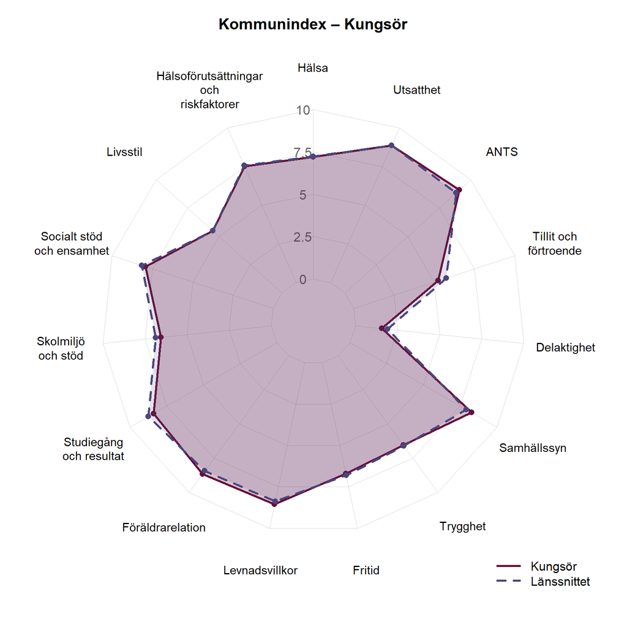

Diagram 1. Indexvärden per område jämfört med länssnittet.

Tabell 1. Kommunens indexvärden per område jämfört med länssnittet, sorterat efter avvikelse.

| Område | Kommunvärde | Länssnittet | Avvikelse |
| --- | --- | --- | --- |
| Tillit och förtroende | 5.25 | 5.74 | -0.49 |
| Delaktighet | 1.55 | 1.90 | -0.35 |
| Samhällssyn | 8.28 | 7.93 | 0.35 |
| Studiegång och resultat | 8.41 | 8.75 | -0.34 |
| Skolmiljö och stöd | 6.55 | 6.88 | -0.33 |
| ANTS | 9.09 | 8.84 | 0.25 |
| Socialt stöd och ensamhet | 7.93 | 8.17 | -0.24 |
| Föräldrarelation | 8.64 | 8.41 | 0.23 |
| Levnadsvillkor | 8.54 | 8.37 | 0.17 |
| Fritid | 6.71 | 6.79 | -0.08 |
| Hälsoförutsättningar och riskfaktorer | 7.51 | 7.56 | -0.05 |
| Trygghet | 6.55 | 6.59 | -0.04 |
| Hälsa | 7.21 | 7.22 | -0.01 |
| Livsstil | 5.50 | 5.49 | 0.01 |
| Utsatthet | 8.86 | 8.87 | -0.01 |

För Kungsör framgår ett mer gynnsamt resultat än länsgenomsnittet på områdena Samhällssyn, ANTS, Föräldrarelation. Det innebär att det sammanvägda indexvärdet för dessa områden överstiger länssnittet, vilket speglar att en större andel av unga i kommunen uppvisar positiva utfall på de indikatorer som bygger upp respektive område.

För Kungsör framgår ett mindre gynnsamt resultat än länsgenomsnittet på områdena Tillit och förtroende, Delaktighet, Studiegång och resultat, Skolmiljö och stöd, Socialt stöd och ensamhet. Det innebär att det inom dessa områden finns ett relativt sett större behov av insatser riktade till unga i Kungsör.

För Kungsör ligger områdena Hälsa, Hälsoförutsättningar och riskfaktorer, Livsstil, Levnadsvillkor, Fritid, Trygghet, Utsatthet nära länssnittet, vilket tyder på att kommunen i stora drag följer det länsövergripande mönstret inom dessa områden.

# Resultat per område

Under respektive område redovisas dels ett sammanvägt indexvärde, dels resultaten för de enskilda indikatorerna som indexet bygger på. Indexvärdet ger en övergripande bild av läget inom området, medan indikatorerna visar vad som driver resultatet och om det finns skillnader mellan killar och tjejer.

## Hälsa

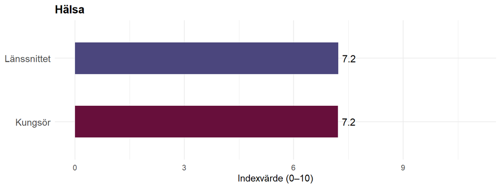

Diagram 2. Indexvärde för Hälsa jämfört med länssnittet.

Resultatet för Kungsör visar en nivå i linje med länsgenomsnittet på området Hälsa (7.2 jämfört med 7.2), vilket innebär att kommunen följer det övergripande mönstret i länet.

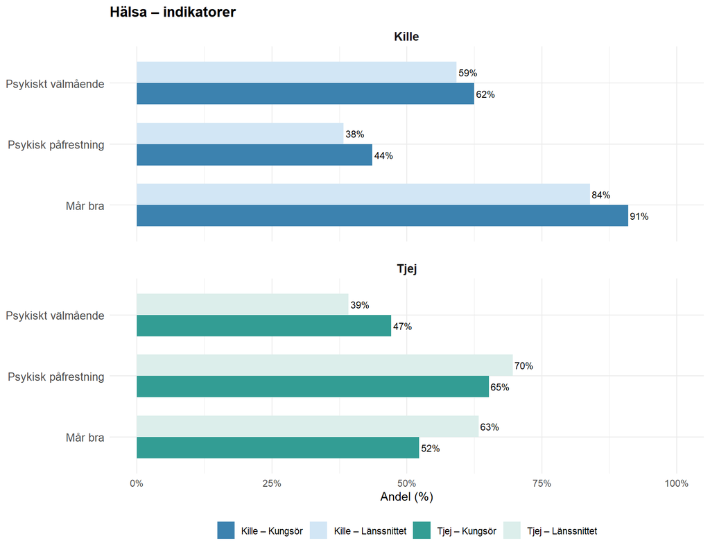

Diagram 3. Indikatorer inom Hälsa - andel per kön jämfört med länssnittet

Tabell 2. Indikatorer inom Hälsa – kommunens värde jämfört med länssnittet.

| Indikator | Kommun (%) | Länssnittet (%) | ± % | Jämfört med länet |
| --- | --- | --- | --- | --- |
| Psykiskt välmående | 56 | 49 | 7 | ▲ Högre |
| Psykisk påfrestning | 54 | 54 | 0 | ▼ Lägre |
| Mår bra | 73 | 74 | 0 | ▼ Lägre |

Kungsörs resultat för området Hälsa ligger i nivå med länets genomsnitt, men på indikatornivå framträder flera tydliga skillnader. Andelen med gott psykiskt välmående är högre än i länet bland både killar och tjejer, framför allt bland tjejer där skillnaden är 8 procentenheter. För andelen som uppger att de mår bra är däremot skillnaderna motsatta, med 7 procentenheter högre andel bland killar och 11 procentenheter lägre bland tjejer. Könsskillnaden i allmänt mående är därmed betydligt större i Kungsör än i länet. Även psykisk påfrestning visar motsatta avvikelser, med högre andel bland killar och lägre bland tjejer jämfört med länet.

## Utsatthet

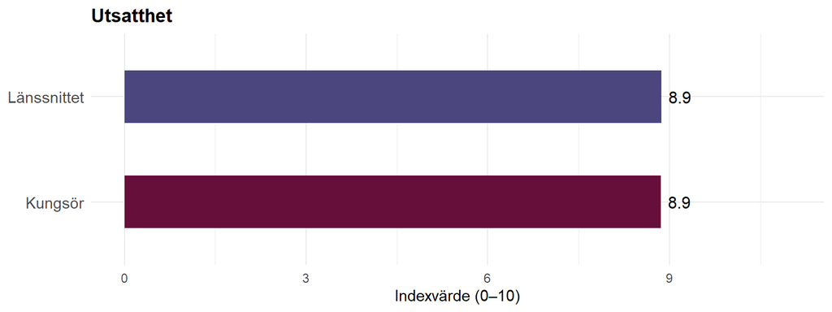

Diagram 4. Indexvärde för Utsatthet jämfört med länssnittet.

Resultatet för Kungsör visar en nivå i linje med länsgenomsnittet på området Utsatthet (8.9 jämfört med 8.9), vilket innebär att kommunen följer det övergripande mönstret i länet.

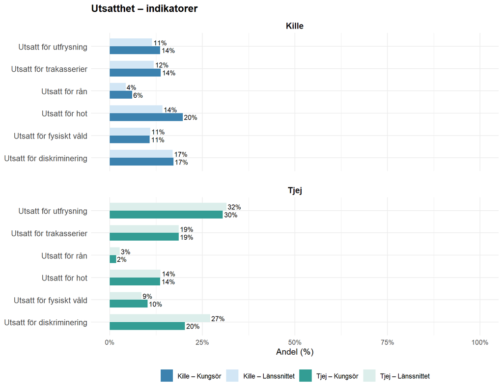

Diagram 5. Indikatorer inom Utsatthet - andel per kön jämfört med länssnittet

Tabell 3. Indikatorer inom Utsatthet – kommunens värde jämfört med länssnittet.

| Indikator | Kommun (%) | Länssnittet (%) | ± % | Jämfört med länet |
| --- | --- | --- | --- | --- |
| Utsatt för diskriminering | 19 | 22 | -4 | ▼ Lägre |
| Utsatt för hot | 17 | 14 | 3 | ▲ Högre |
| Utsatt för trakasserier | 16 | 15 | 1 | ▲ Högre |
| Utsatt för fysiskt våld | 10 | 10 | 1 | ▲ Högre |
| Utsatt för rån | 4 | 3 | 1 | ▲ Högre |
| Utsatt för utfrysning | 22 | 22 | 0 | ▼ Lägre |

Kungsörs resultat för området Utsatthet ligger i nivå med länets genomsnitt. På indikatornivå är skillnaderna överlag små, men vissa avvikelser framträder. Framför allt är andelen tjejer som uppger att de utsatts för diskriminering 7 procentenheter lägre än i länet. Bland killar är däremot utsatthet för hot mer utbredd, med en andel som är 6 procentenheter högre än i länet. För övriga indikatorer ligger resultaten relativt nära länsnivån. Könsskillnaderna följer i huvudsak länets mönster, där utfrysning är betydligt vanligare bland tjejer än bland killar, medan skillnaden mellan könen är mindre för diskriminering.

## ANTS

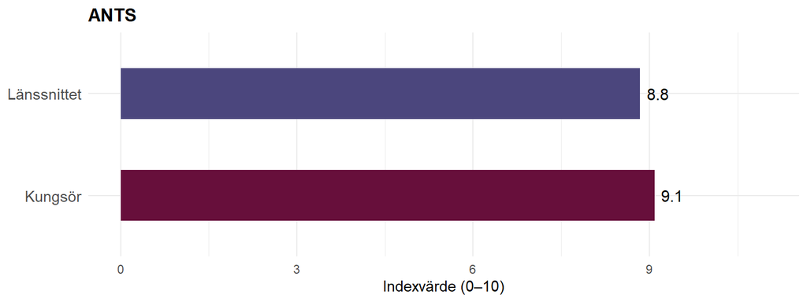

Diagram 6. Indexvärde för ANTS jämfört med länssnittet.

Resultatet för Kungsör visar en mer gynnsam nivå på området ANTS jämfört med länsgenomsnittet (9.1 jämfört med 8.8), vilket tyder på att kommunen överlag har mer gynnsamma utfall för de indikatorer som ingår i området.

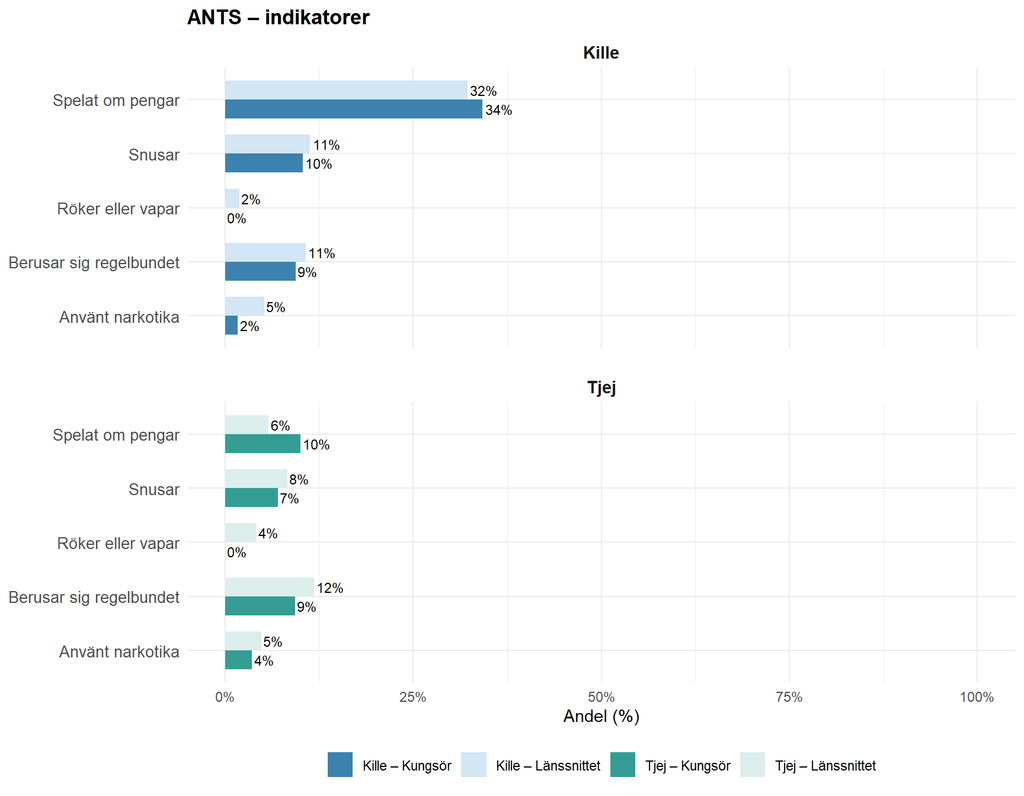

Diagram 7. Indikatorer inom ANTS - andel per kön jämfört med länssnittet

Tabell 4. Indikatorer inom ANTS – kommunens värde jämfört med länssnittet.

| Indikator | Kommun (%) | Länssnittet (%) | ± % | Jämfört med länet |
| --- | --- | --- | --- | --- |
| Spelat om pengar | 24 | 19 | 5 | ▲ Högre |
| Röker eller vapar | 0 | 3 | -3 | ▼ Lägre |
| Använt narkotika | 3 | 5 | -2 | ▼ Lägre |
| Berusar sig regelbundet | 9 | 11 | -2 | ▼ Lägre |
| Snusar | 9 | 10 | -1 | ▼ Lägre |

Kungsör har ett mer gynnsamt resultat inom området ANTS jämfört med länet, men på indikatornivå är bilden blandad. Framför allt är rökning och vaping mindre vanligt förekommande, då ingen av de svarande i Kungsör uppger att de röker eller vapar. Även narkotikaanvändning och regelbundet berusningsdrickande är mindre vanliga bland både killar och tjejer. Bland killar är andelen som använt narkotika 2 % i Kungsör jämfört med 5 % i länet. Spel om pengar är däremot vanligare i Kungsör, särskilt bland tjejer, där andelen är 10 % jämfört med 6 % i länet. Könsskillnaderna följer i huvudsak länets mönster, där spel om pengar är betydligt vanligare bland killar än bland tjejer.

## Tillit och förtroende

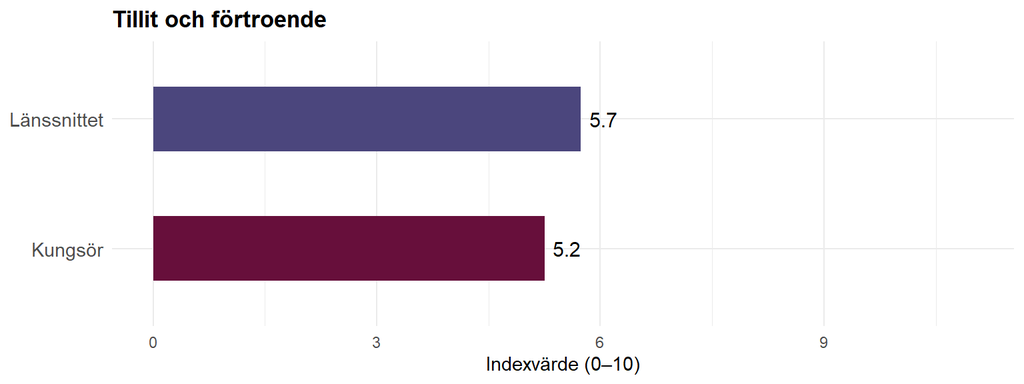

Diagram 8. Indexvärde för Tillit och förtroende jämfört med länssnittet.

Resultatet för Kungsör visar en mindre gynnsam nivå på området Tillit och förtroende jämfört med länsgenomsnittet (5.2 jämfört med 5.7), vilket tyder på att kommunen överlag har mindre gynnsamma utfall för de indikatorer som ingår i området.

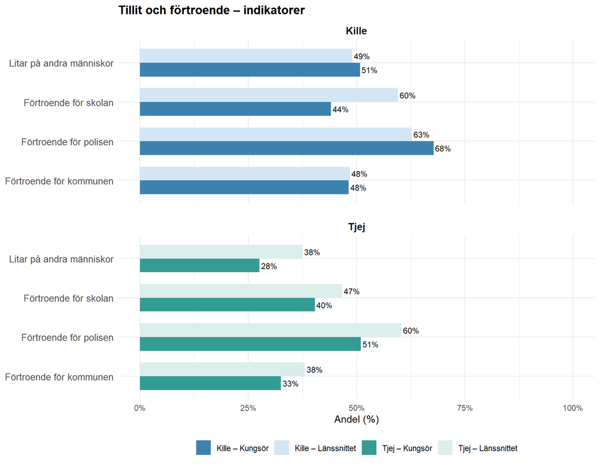

Diagram 9. Indikatorer inom Tillit och förtroende - andel per kön jämfört med länssnittet

Tabell 5. Indikatorer inom Tillit och förtroende – kommunens värde jämfört med länssnittet.

| Indikator | Kommun (%) | Länssnittet (%) | ± % | Jämfört med länet |
| --- | --- | --- | --- | --- |
| Förtroende för skolan | 42 | 53 | -11 | ▼ Lägre |
| Litar på andra människor | 40 | 43 | -3 | ▼ Lägre |
| Förtroende för kommunen | 41 | 43 | -2 | ▼ Lägre |
| Förtroende för polisen | 60 | 62 | -1 | ▼ Lägre |

Kungsörs resultat för området Tillit och förtroende är mindre gynnsamt än länets genomsnitt. Den tydligaste avvikelsen gäller förtroendet för skolan, där andelen är 16 procentenheter lägre bland killar och 7 procentenheter lägre bland tjejer jämfört med länet. Även tilliten till andra människor är betydligt lägre bland tjejer i Kungsör, med en skillnad på 10 procentenheter, medan killarna ligger nära länsnivån. Förtroendet för polisen visar motsatta mönster mellan könen, med 9 procentenheter lägre andel bland tjejer och 5 procentenheter högre bland killar. Könsskillnaderna är större än i länet för flera indikatorer, särskilt tilliten till andra människor, där skillnaden är 23 procentenheter i Kungsör jämfört med 11 i länet.

## Delaktighet

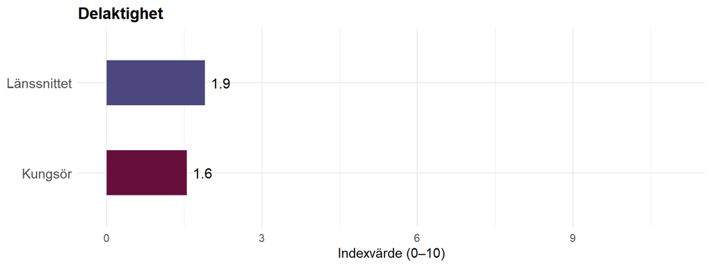

Diagram 10. Indexvärde för Delaktighet jämfört med länssnittet.

Resultatet för Kungsör visar en mindre gynnsam nivå på området Delaktighet jämfört med länsgenomsnittet (1.6 jämfört med 1.9), vilket tyder på att kommunen överlag har mindre gynnsamma utfall för de indikatorer som ingår i området.

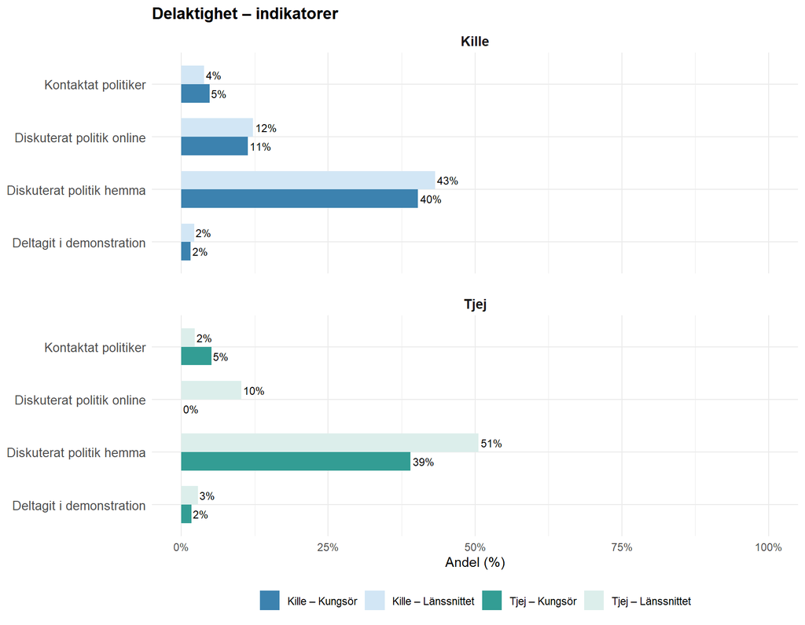

Diagram 11. Indikatatorer inom Delaktighet - andel per kön jämfört med länssnittet

Tabell 6. Indikatorer inom Delaktighet – kommunens värde jämfört med länssnittet.

| Indikator | Kommun (%) | Länssnittet (%) | ± % | Jämfört med länet |
| --- | --- | --- | --- | --- |
| Diskuterat politik hemma | 40 | 47 | -7 | ▼ Lägre |
| Diskuterat politik online | 6 | 11 | -5 | ▼ Lägre |
| Kontaktat politiker | 5 | 3 | 2 | ▲ Högre |
| Deltagit i demonstration | 2 | 2 | -1 | ▼ Lägre |

Kungsörs resultat för området Delaktighet är mindre gynnsamt än länets genomsnitt, vilket framför allt syns bland tjejer. Andelen tjejer som diskuterat politik hemma är 12 procentenheter lägre än i länet, och ingen av tjejerna uppger att de diskuterat politik online, jämfört med 10 % i länet. Bland killar är skillnaderna mot länet betydligt mindre. Kontakt med politiker är däremot något vanligare bland tjejer i Kungsör, även om andelarna är små. Könsmönstret skiljer sig också från länet, där tjejer oftare diskuterar politik hemma än killar, medan andelarna är ungefär lika stora i Kungsör.

## Samhällssyn

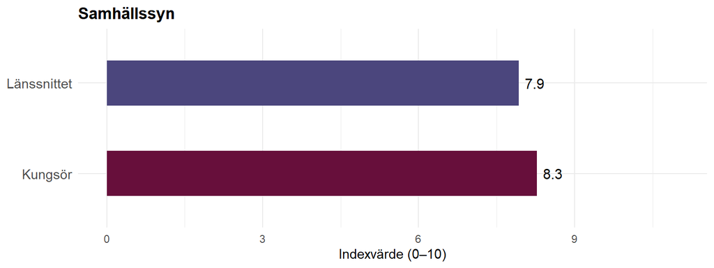

Diagram 12. Indexvärde för Samhällssyn jämfört med länssnittet.

Resultatet för Kungsör visar en mer gynnsam nivå på området Samhällssyn jämfört med länsgenomsnittet (8.3 jämfört med 7.9), vilket tyder på att kommunen överlag har mer gynnsamma utfall för de indikatorer som ingår i området.

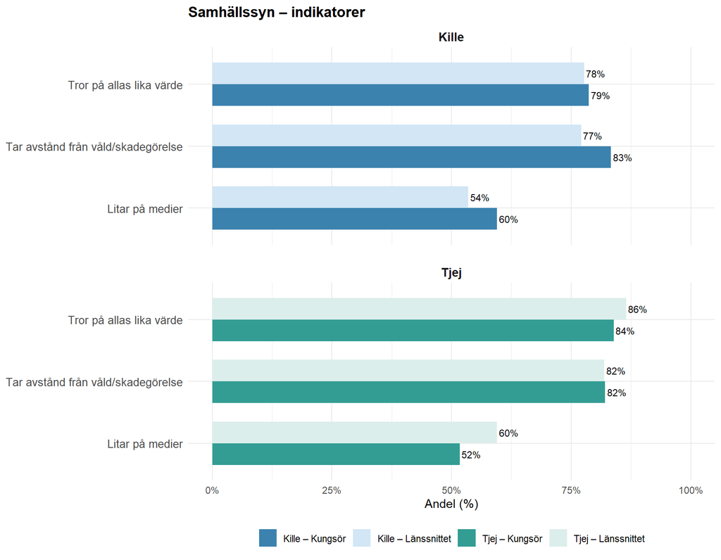

Diagram 13. Indikatorer inom Samhällssyn - andel per kön jämfört med länssnittet

Tabell 7. Indikatorer inom Samhällssyn – kommunens värde jämfört med länssnittet.

| Indikator | Kommun (%) | Länssnittet (%) | ± % | Jämfört med länet |
| --- | --- | --- | --- | --- |
| Tar avstånd från våld/skadegörelse | 83 | 80 | 3 | ▲ Högre |
| Tror på allas lika värde | 81 | 82 | -1 | ▼ Lägre |
| Litar på medier | 56 | 56 | 0 | ▼ Lägre |

Kungsör har ett mer gynnsamt resultat inom området Samhällssyn jämfört med länet, men på indikatornivå framträder vissa skillnader mellan könen. Framför allt är andelen killar som tar avstånd från våld och skadegörelse 6 procentenheter högre än i länet, medan tjejer ligger på länsnivån. Tilliten till medier visar däremot motsatta resultat, med 6 procentenheter högre andel bland killar och 8 procentenheter lägre bland tjejer. Könsmönstret för tilliten till medier är därmed det omvända jämfört med länet. För tron på allas lika värde är skillnaderna mot länet små bland både killar och tjejer.

## Trygghet

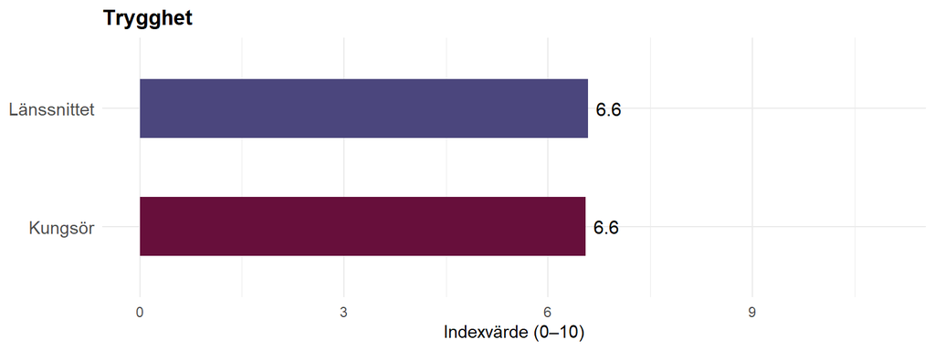

Diagram 14. Indexvärde för Trygghet jämfört med länssnittet.

Resultatet för Kungsör visar en nivå i linje med länsgenomsnittet på området Trygghet (6.6 jämfört med 6.6), vilket innebär att kommunen följer det övergripande mönstret i länet.

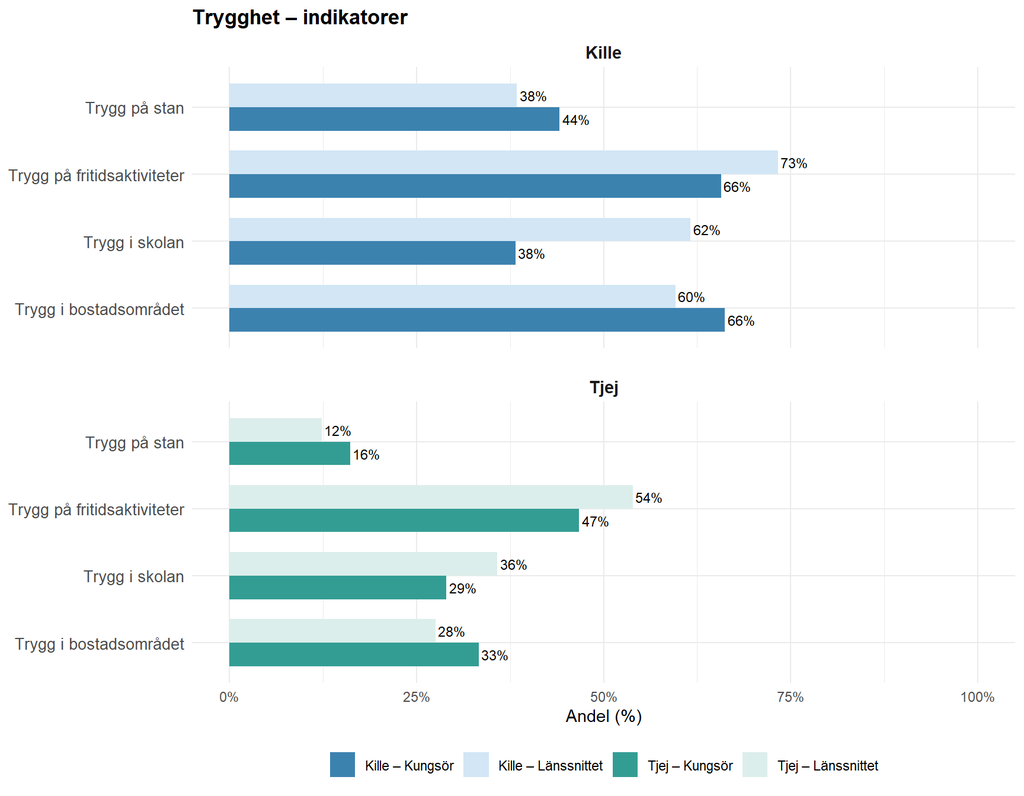

Diagram 15. Indikatorer inom Trygghet - andel per kön jämfört med länssnittet

Tabell 8. Indikatorer inom Trygghet – kommunens värde jämfört med länssnittet.

| Indikator | Kommun (%) | Länssnittet (%) | ± % | Jämfört med länet |
| --- | --- | --- | --- | --- |
| Trygg i skolan | 34 | 48 | -15 | ▼ Lägre |
| Trygg i bostadsområdet | 50 | 43 | 7 | ▲ Högre |
| Trygg på fritidsaktiviteter | 57 | 63 | -7 | ▼ Lägre |
| Trygg på stan | 31 | 25 | 6 | ▲ Högre |

Kungsörs resultat för området Trygghet ligger i nivå med länets genomsnitt, men på indikatornivå framträder stora skillnader i olika riktningar. Framför allt är tryggheten i skolan betydligt lägre än i länet, särskilt bland killar där andelen är 24 procentenheter lägre. Även tryggheten på fritidsaktiviteter är 7 procentenheter lägre bland både killar och tjejer. Däremot är tryggheten i bostadsområdet och på stan högre i Kungsör än i länet för båda könen. Könsskillnaderna är överlag stora, men för trygghet i skolan är skillnaden mellan killar och tjejer betydligt mindre än i länet, vilket framför allt beror på killarnas lägre trygghet.

## Fritid

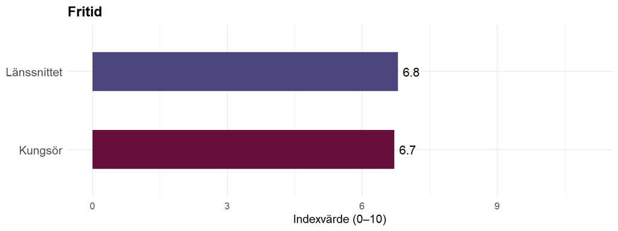

Diagram 16. Indexvärde för Fritid jämfört med länssnittet.

Resultatet för Kungsör visar en nivå i linje med länsgenomsnittet på området Fritid (6.7 jämfört med 6.8), vilket innebär att kommunen följer det övergripande mönstret i länet.

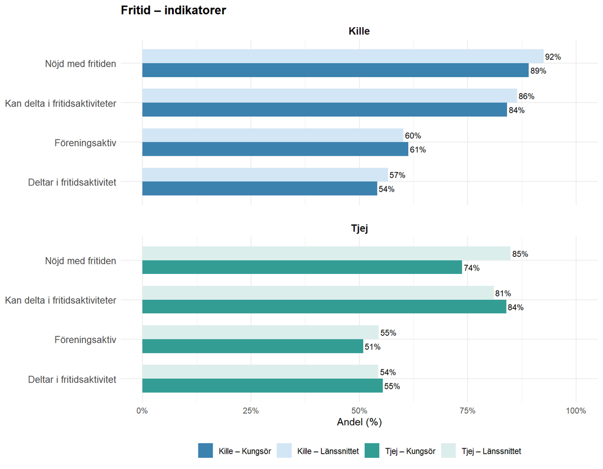

Diagram 17. Indikatorer inom Fritid - andel per kön jämfört med länssnittet

Tabell 9. Indikatorer inom Fritid – kommunens värde jämfört med länssnittet.

| Indikator | Kommun (%) | Länssnittet (%) | ± % | Jämfört med länet |
| --- | --- | --- | --- | --- |
| Nöjd med fritiden | 82 | 89 | -7 | ▼ Lägre |
| Föreningsaktiv | 56 | 57 | -1 | ▼ Lägre |
| Deltar i fritidsaktivitet | 55 | 56 | -1 | ▼ Lägre |
| Kan delta i fritidsaktiviteter | 84 | 84 | 0 | ▲ Högre |

Kungsörs resultat för området Fritid ligger nära länets genomsnitt, men på indikatornivå framträder en tydlig skillnad i nöjdheten med fritiden. Framför allt är andelen tjejer som är nöjda med sin fritid 11 procentenheter lägre än i länet, medan skillnaden bland killar är betydligt mindre. Samtidigt ligger tjejernas deltagande i fritidsaktiviteter och möjligheten att delta i önskade aktiviteter i nivå med eller något över länets resultat. Könsskillnaden i nöjdhet med fritiden är därmed också betydligt större i Kungsör än i länet som helhet. För övriga indikatorer är skillnaderna mot länet relativt små, både bland killar och tjejer.

## Levnadsvillkor

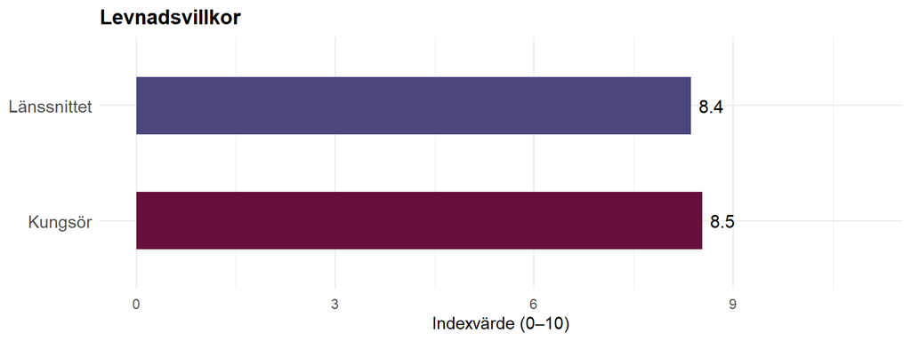

Diagram 18. Indexvärde för Levnadsvillkor jämfört med länssnittet.

Resultatet för Kungsör visar en nivå i linje med länsgenomsnittet på området Levnadsvillkor (8.5 jämfört med 8.4), vilket innebär att kommunen följer det övergripande mönstret i länet.

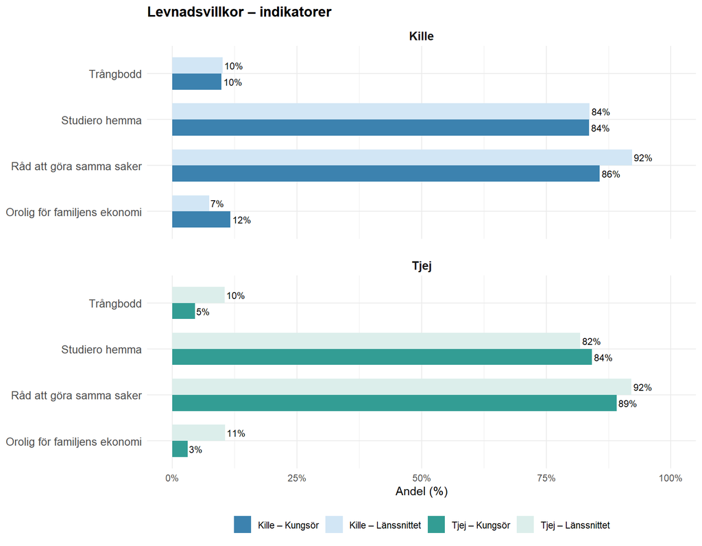

Diagram 19. Indikatorer inom Levnadsvillkor - andel per kön jämfört med länssnittet

Tabell 10. Indikatorer inom Levnadsvillkor – kommunens värde jämfört med länssnittet.

| Indikator | Kommun (%) | Länssnittet (%) | ± % | Jämfört med länet |
| --- | --- | --- | --- | --- |
| Råd att göra samma saker | 87 | 92 | -5 | ▼ Lägre |
| Trångbodd | 7 | 10 | -3 | ▼ Lägre |
| Studiero hemma | 84 | 83 | 1 | ▲ Högre |
| Orolig för familjens ekonomi | 8 | 9 | -1 | ▼ Lägre |

Kungsörs resultat för området Levnadsvillkor ligger i nivå med länets genomsnitt, men på indikatornivå framträder vissa skillnader. Andelen som har råd att göra och köpa samma saker som andra är lägre bland både killar och tjejer, med 6 respektive 4 procentenheter jämfört med länet. Oro för familjens ekonomi visar däremot motsatta mönster mellan könen. Bland killar är andelen 5 procentenheter högre än i länet, medan den bland tjejer är 8 procentenheter lägre. Könsmönstret för ekonomisk oro är därmed det omvända jämfört med länet. Även trångboddhet är mindre vanlig bland tjejer i Kungsör, 5 % jämfört med 10 % i länet. För studiero hemma ligger resultaten nära länsnivån.

## Föräldrarelation

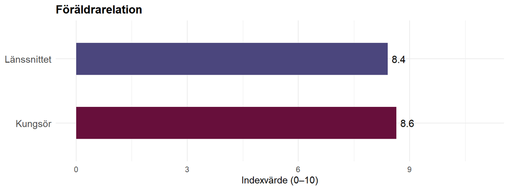

Diagram 20. Indexvärde för Föräldrarelation jämfört med länssnittet.

Resultatet för Kungsör visar en mer gynnsam nivå på området Föräldrarelation jämfört med länsgenomsnittet (8.6 jämfört med 8.4), vilket tyder på att kommunen överlag har mer gynnsamma utfall för de indikatorer som ingår i området.

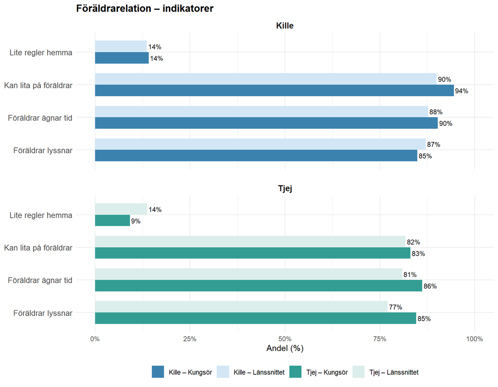

Diagram 21. Indikatorer inom Föräldrarelation - andel per kön jämfört med länssnittet

Tabell 11. Indikatorer inom Föräldrarelation – kommunens värde jämfört med länssnittet.

| Indikator | Kommun (%) | Länssnittet (%) | ± % | Jämfört med länet |
| --- | --- | --- | --- | --- |
| Föräldrar ägnar tid | 88 | 84 | 4 | ▲ Högre |
| Kan lita på föräldrar | 89 | 86 | 3 | ▲ Högre |
| Föräldrar lyssnar | 85 | 82 | 3 | ▲ Högre |
| Lite regler hemma | 12 | 14 | -2 | ▼ Lägre |

Kungsör har ett något mer gynnsamt resultat inom området Föräldrarelation jämfört med länet. På indikatornivå framträder framför allt mer gynnsamma resultat bland tjejer, där andelen som uppger att föräldrar lyssnar är 8 procentenheter högre än i länet och andelen som upplever att föräldrar ägnar tid är 5 procentenheter högre. Bland killar är det framför allt andelen som uppger att de kan lita på sina föräldrar som är högre än i länet, med 4 procentenheter. Könsskillnaderna är överlag mindre i Kungsör än i länet, särskilt när det gäller upplevelsen av att föräldrar lyssnar, där andelen är lika stor bland killar och tjejer i Kungsör.

## Studiegång och resultat

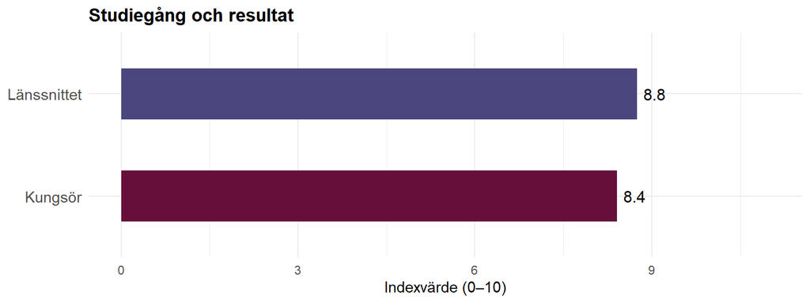

Diagram 22. Indexvärde för Studiegång och resultat jämfört med länssnittet.

Resultatet för Kungsör visar en mindre gynnsam nivå på området Studiegång och resultat jämfört med länsgenomsnittet (8.4 jämfört med 8.8), vilket tyder på att kommunen överlag har mindre gynnsamma utfall för de indikatorer som ingår i området.

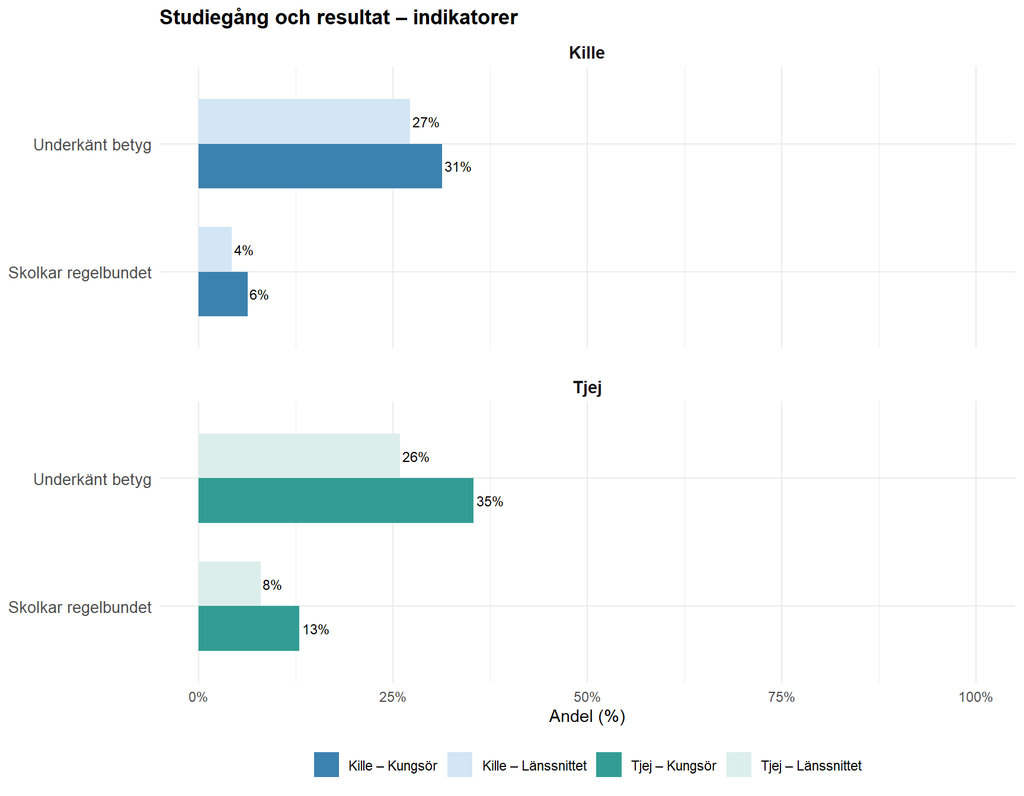

Diagram 23. Indikatorer inom Studiegång och resultat - andel per kön jämfört med länssnittet

Tabell 12. Indikatorer inom Studiegång och resultat – kommunens värde jämfört med länssnittet.

| Indikator | Kommun (%) | Länssnittet (%) | ± % | Jämfört med länet |
| --- | --- | --- | --- | --- |
| Underkänt betyg | 33 | 26 | 7 | ▲ Högre |
| Skolkar regelbundet | 10 | 6 | 3 | ▲ Högre |

Kungsörs resultat för området Studiegång och resultat är mindre gynnsamt än länets genomsnitt. Framför allt är andelen som rapporterar underkända betyg högre, särskilt bland tjejer där skillnaden är 9 procentenheter jämfört med länet. Även regelbundet skolk är vanligare i Kungsör, med en skillnad på 5 procentenheter bland tjejer och 2 procentenheter bland killar. Avvikelserna mot länet är därmed större bland tjejer för båda indikatorerna. Könsmönstret för underkända betyg skiljer sig också från länet, då andelen är högre bland tjejer än killar i Kungsör, medan det motsatta gäller i länet.

## Skolmiljö och stöd

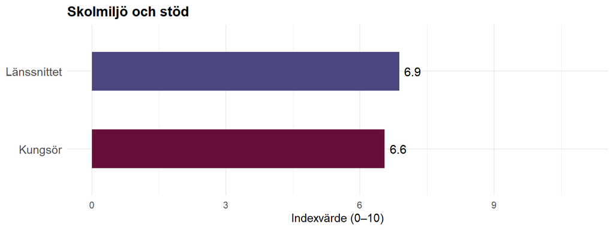

Diagram 24. Indexvärde för Skolmiljö och stöd jämfört med länssnittet.

Resultatet för Kungsör visar en mindre gynnsam nivå på området Skolmiljö och stöd jämfört med länsgenomsnittet (6.6 jämfört med 6.9), vilket tyder på att kommunen överlag har mindre gynnsamma utfall för de indikatorer som ingår i området.

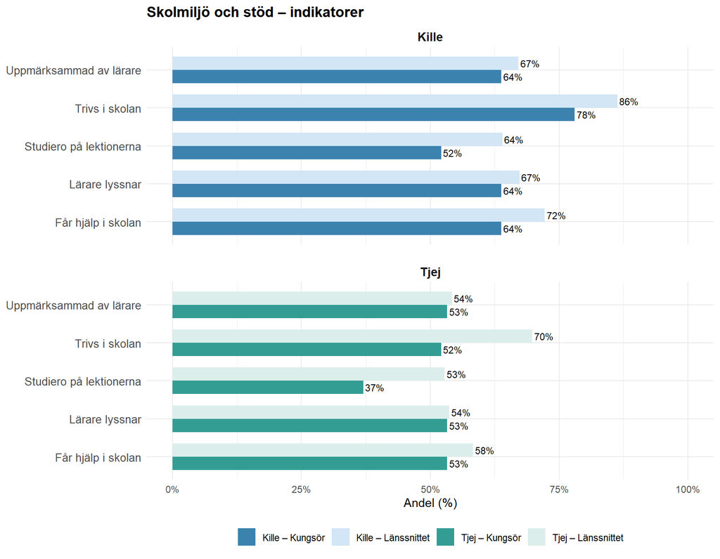

Diagram 25. Indikatorer inom Skolmiljö och stöd - andel per kön jämfört med länssnittet

Tabell 13. Indikatorer inom Skolmiljö och stöd – kommunens värde jämfört med länssnittet.

| Indikator | Kommun (%) | Länssnittet (%) | ± % | Jämfört med länet |
| --- | --- | --- | --- | --- |
| Studiero på lektionerna | 45 | 58 | -13 | ▼ Lägre |
| Trivs i skolan | 65 | 78 | -12 | ▼ Lägre |
| Får hjälp i skolan | 59 | 65 | -6 | ▼ Lägre |
| Uppmärksammad av lärare | 59 | 60 | -2 | ▼ Lägre |
| Lärare lyssnar | 59 | 60 | -2 | ▼ Lägre |

Kungsörs mindre gynnsamma resultat inom området Skolmiljö och stöd syns framför allt i lägre skoltrivsel och studiero. Skillnaderna mot länet är särskilt stora bland tjejer, där andelen som trivs i skolan är 18 procentenheter lägre och andelen som upplever studiero på lektionerna är 16 procentenheter lägre. Även bland killar är resultaten mindre gynnsamma, framför allt för studiero och skoltrivsel. Andelen som uppger att de får hjälp i skolan är också lägre bland båda könen. Könsskillnaderna följer i huvudsak länets mönster, men är större i Kungsör, särskilt för skoltrivsel.

## Socialt stöd och ensamhet

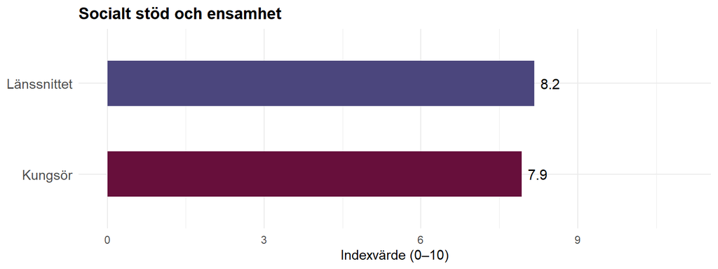

Diagram 26. Indexvärde för Socialt stöd och ensamhet jämfört med länssnittet.

Resultatet för Kungsör visar en mindre gynnsam nivå på området Socialt stöd och ensamhet jämfört med länsgenomsnittet (7.9 jämfört med 8.2), vilket tyder på att kommunen överlag har mindre gynnsamma utfall för de indikatorer som ingår i området.

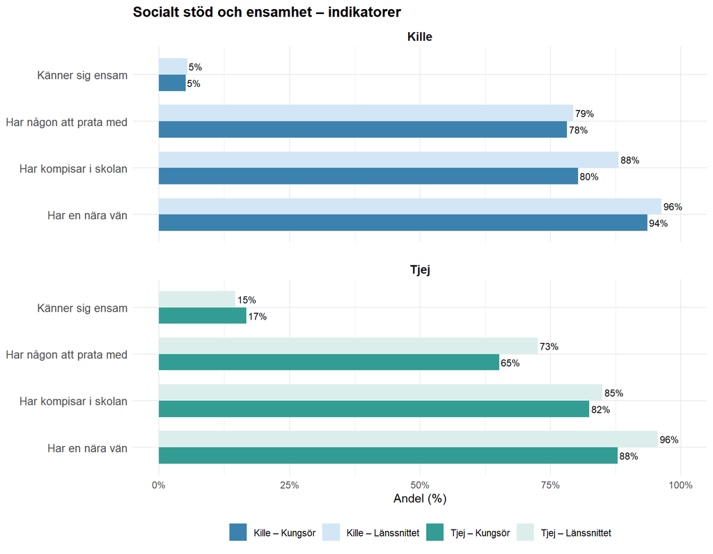

Diagram 27. Indikatorer inom Socialt stöd och ensamhet - andel per kön jämfört med länssnittet

Tabell 14. Indikatorer inom Socialt stöd och ensamhet – kommunens värde jämfört med länssnittet.

| Indikator | Kommun (%) | Länssnittet (%) | ± % | Jämfört med länet |
| --- | --- | --- | --- | --- |
| Har kompisar i skolan | 81 | 86 | -5 | ▼ Lägre |
| Har en nära vän | 91 | 96 | -5 | ▼ Lägre |
| Har någon att prata med | 72 | 76 | -4 | ▼ Lägre |
| Känner sig ensam | 10 | 10 | 0 | ▲ Högre |

Kungsörs resultat för området Socialt stöd och ensamhet är mindre gynnsamt än länets genomsnitt. På indikatornivå framträder olika avvikelser bland tjejer och killar. Bland tjejer är framför allt andelarna som har en nära vän respektive någon att prata med 8 procentenheter lägre än i länet. Bland killar är den tydligaste avvikelsen andelen som har kompisar i skolan, som också är 8 procentenheter lägre än i länet. Andelen som känner sig ensamma ligger däremot nära länsnivån för båda könen. Könsskillnaderna är större än i länet när det gäller att ha någon att prata med, medan könsmönstret är det omvända för att ha kompisar i skolan.

## Livsstil

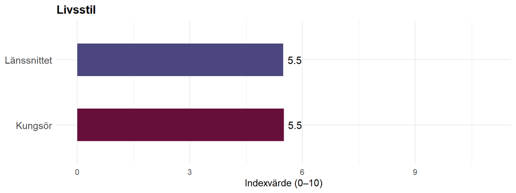

Diagram 29. Indexvärde för Livsstil jämfört med länssnittet.

Resultatet för Kungsör visar en nivå i linje med länsgenomsnittet på området Livsstil (5.5 jämfört med 5.5), vilket innebär att kommunen följer det övergripande mönstret i länet.

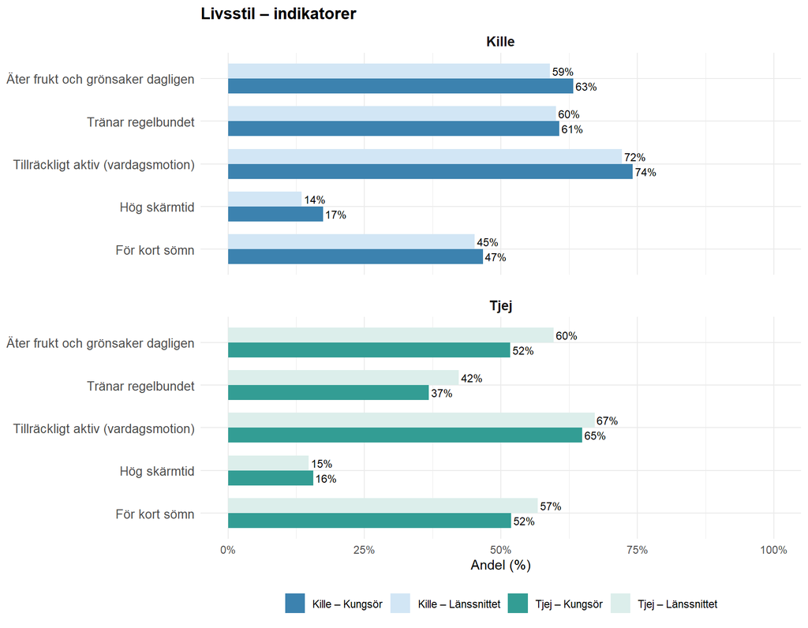

Diagram 30. Indikatorer inom Livsstil - andel per kön jämfört med länssnittet

Tabell 15. Indikatorer inom Livsstil – kommunens värde jämfört med länssnittet.

| Indikator | Kommun (%) | Länssnittet (%) | ± % | Jämfört med länet |
| --- | --- | --- | --- | --- |
| Hög skärmtid | 16 | 14 | 2 | ▲ Högre |
| För kort sömn | 49 | 51 | -2 | ▼ Lägre |
| Äter frukt och grönsaker dagligen | 58 | 59 | -2 | ▼ Lägre |
| Tränar regelbundet | 49 | 51 | -2 | ▼ Lägre |
| Tillräckligt aktiv (vardagsmotion) | 70 | 70 | 0 | ▲ Högre |

Kungsörs resultat för området Livsstil ligger i nivå med länets genomsnitt, men på indikatornivå framträder vissa skillnader mellan könen. Framför allt är andelen tjejer som äter frukt och grönsaker dagligen 8 procentenheter lägre än i länet, medan motsvarande andel bland killar är 4 procentenheter högre. Även regelbunden träning är mindre vanlig bland tjejer, med en andel som är 5 procentenheter lägre än i länet, medan killarna ligger nära länsnivån. Andelen med för kort sömn är däremot något lägre bland tjejer i Kungsör. Könsskillnaderna är större än i länet för både frukt- och grönsakskonsumtion och regelbunden träning. För övriga indikatorer är skillnaderna mot länet relativt små.